# Report of the 2021 ERIM Open Science Survey

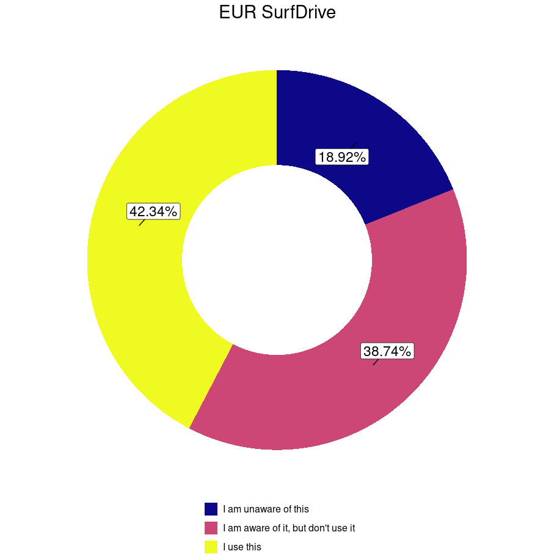

For EUR Dropbox, almost 50% of the respondents do not use it and the other 50% do use it.

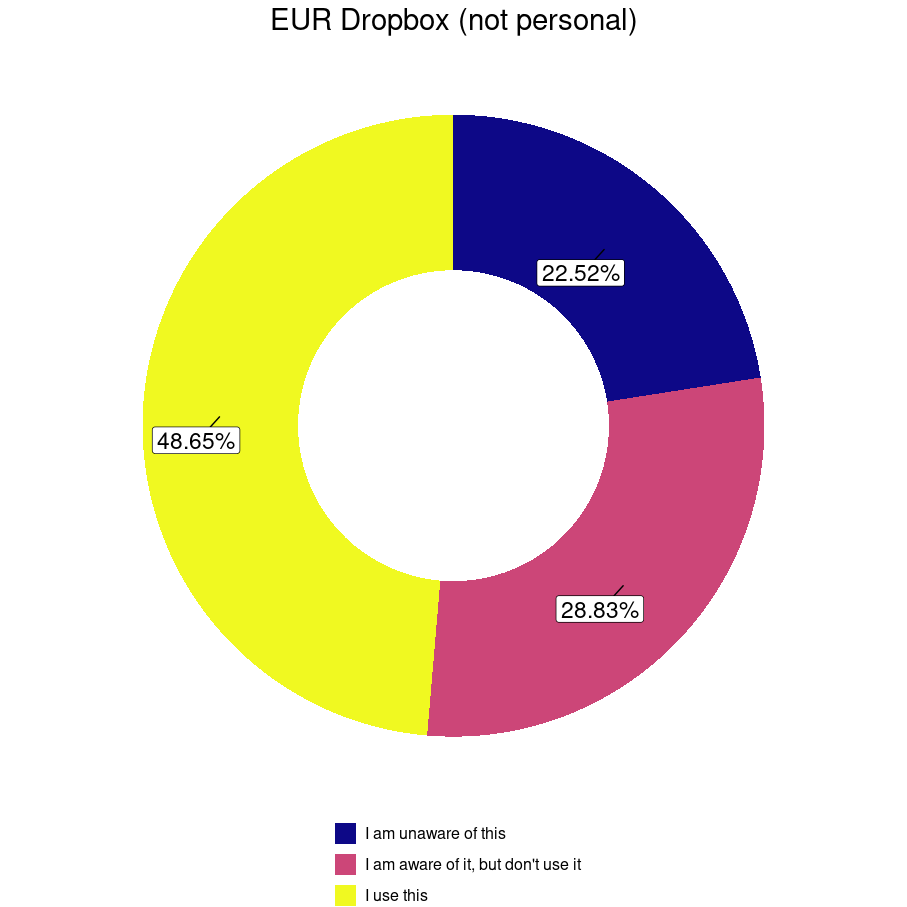

As for the FAIR principles, more than 75% of the researchers do not use them and only a bit less than 15% use them.

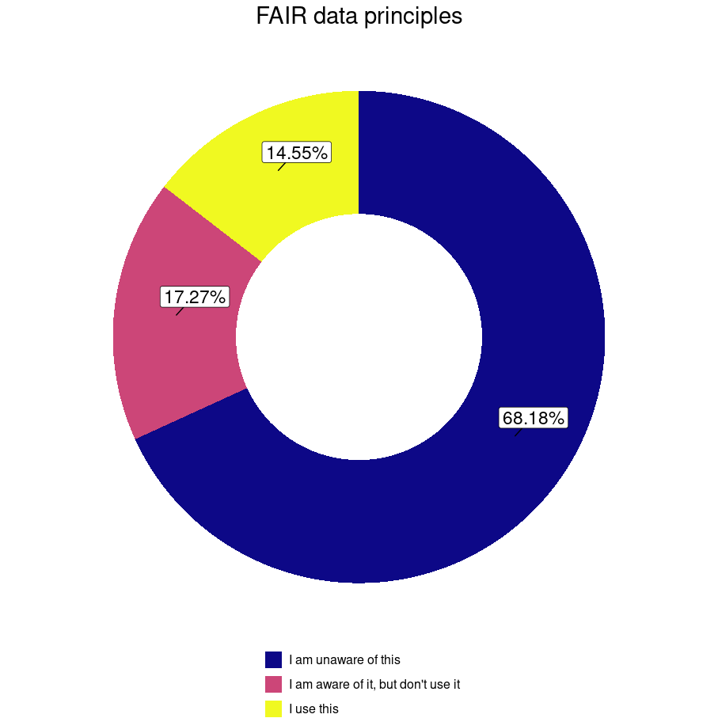

EUR RePub, it is now depicted, and PURE is the new repository for publications, but at the time the survey was done, only a bit more then 33% of the respondents used it and the rest did not use it.

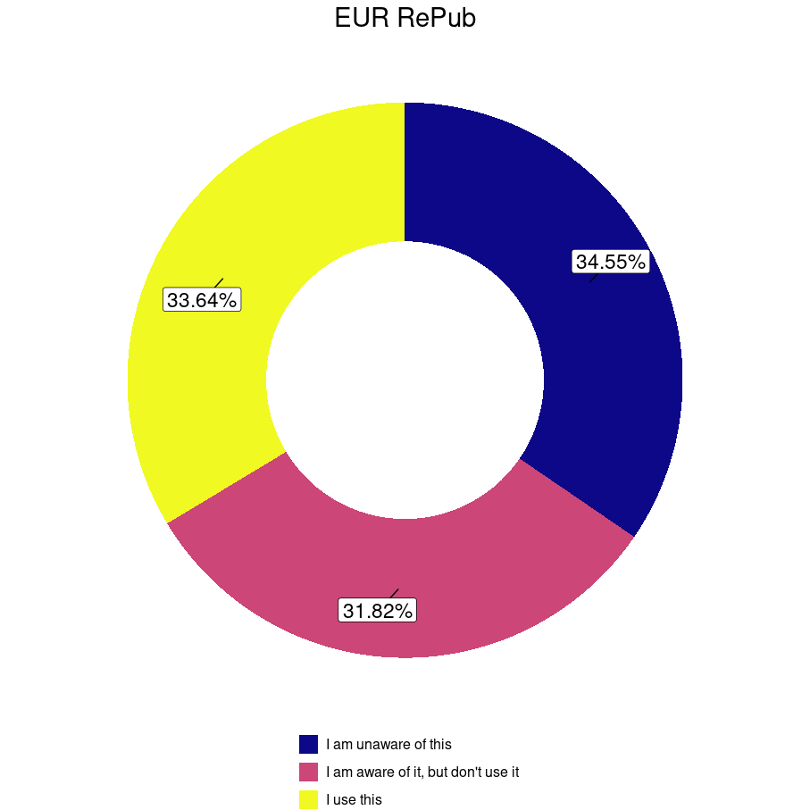

As for Zenodo, less than 1% of the respondents use it, and most researchers are totally unaware of it.

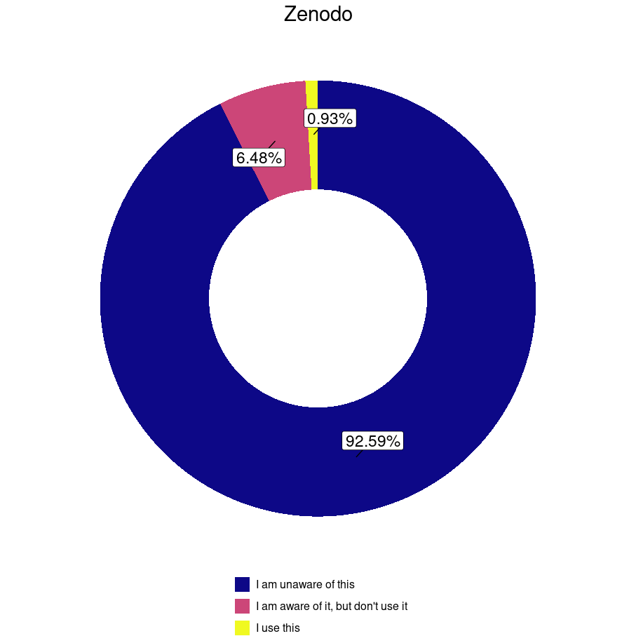

# Role of ERIM

In the question “Do you expect that ERIM supports you in learning open science practice?” researchers were asked if they expected ERIM to support them in learning Open Science practices, almost 70% of respondents said yes while only 16% said no.

```r
# # summary of responses to cluster 9
# cluster9 <-
#   ERIM_OS_clean %>%
#   dplyr::filter(
#     Finished == "TRUE" & # keep only complete questionnaires
#       cluster == "9" # keep only questions of relevant cluster
#   ) %>%
#   droplevels() %>% # drop unused levels
#   dplyr::select(-c(Finished, cluster)) %>% # drop unused columns
#   dplyr::select_if(~ sum(!is.na(.)) > 0) %>% # keep columns without NAs
#   # drop_na() %>% # drop rows with missing values
#   rename("item" = "value_1") %>%
#   group_by(question, item) %>%
#   summarize(number_responses = n()) %>%
#   group_by(question) %>%
#   mutate(
#     perc = round(number_responses / sum(number_responses) * 100, 2), # calculate percentage
#     lab_perc = paste(perc, "%", sep = "") # percentage as text (for labels)
#   ) %>%
#   ungroup()
```

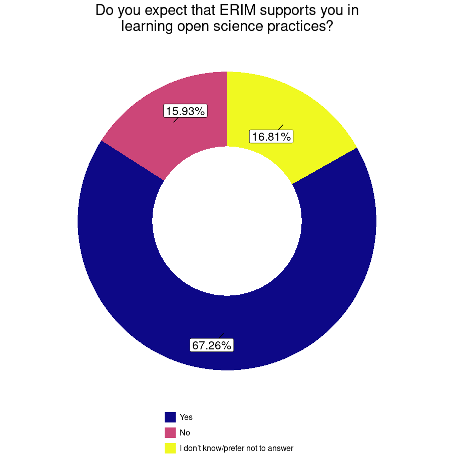

```r
#
# cluster9 %>%
#   dplyr::select(-c(number_responses, perc)) %>%
#   rename(percentage = lab_perc) %>%
#   kable_custom()

# Add images from 10_cluster9_figure.R
```

From the question “Which of the following open science practices would you like ERIM to provide information or support for?”, the top 3 Open Science practices that respondents would like to get information or support for are:

50% - Preregistration

18.42% - Open materials and/or code

14.47% - Open access publishing

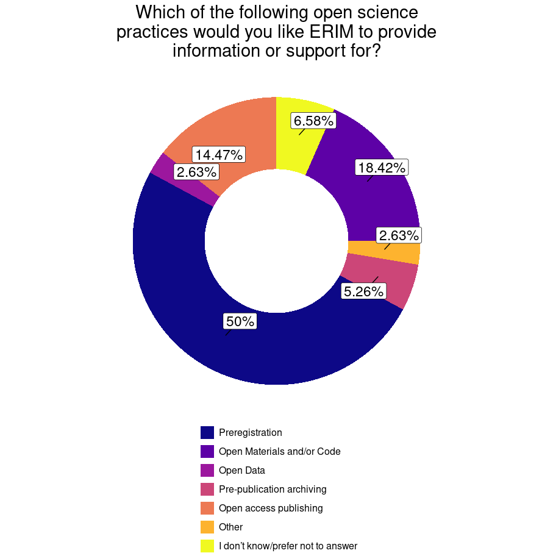

# ERIM Open Science Strategy

ERIM is committed to Open Science. The main reason why we conducted this survey is that we needed to know where the gaps are.

[^1]: The percentages presented in the survey responses reflect the survey respondents, not the total number of researchers at each school.